# Tutorial 3: An Agent That Learns

Slot machines, trial and error, and the explore–exploit dilemma

**NoteWord list（単語リスト）**

| English | 日本語 | Meaning |
| --- | --- | --- |
| agent | エージェント | a (simulated) individual that makes choices |
| reward | 報酬 | the points/food/money an agent receives |
| value estimate | 価値の推定 | the agent’s guess about how good an option is |
| learning rate | 学習率 | how quickly the agent updates its guess |
| explore / exploit | 探索・活用 | try something new / stick with what works |

## The slot machine problem

Imagine two slot machines（スロットマシン）:

- Machine A pays a coin **30%** of the time
- Machine B pays a coin **70%** of the time

You do **not** know these numbers. You have 100 turns. How do you find the good machine — and how do you get rich?

This is called the **multi-armed bandit problem**, and it is one of the most famous problems in psychology, neuroscience, and AI. New restaurant or favourite restaurant? New song or favourite playlist? Same problem: **explore** or **exploit**?

Today we build an **agent**: a small simulated creature that faces this problem and *learns from experience*.

## Idea 1: keep a value estimate for each option

Our agent keeps a number $Q$ for each machine — its current guess of “how good is this machine?” Both start at 0 (no idea).

After every play, the agent updates its guess:

$$Q_{\text{new}} = Q_{\text{old}} + \alpha \times (\text{reward} - Q_{\text{old}})$$

The part $(\text{reward} - Q_{\text{old}})$ is the **prediction error**: *“how different was reality from what I expected?”*

- Got a coin ($1$) when you expected little ($Q=0.2$)? Positive surprise → $Q$ goes **up**.
- Got nothing ($0$) when you expected a lot ($Q=0.8$)? Negative surprise → $Q$ goes **down**.

The **learning rate** $\alpha$ (alpha, between 0 and 1) controls how big each update is: how much the newest experience counts.

```r
alpha <- 0.3
Q <- 0                      # current guess for one machine
reward <- 1                 # we just won a coin!
Q <- Q + alpha * (reward - Q)
Q
```

```
[1] 0.3
```

Run the update in your head: if we keep winning, $Q$ climbs toward 1.

**Note**

This little rule is famous. It is called the **Rescorla–Wagner rule**, and brain cells that release dopamine really do signal prediction errors — this model helped scientists discover that!

## Idea 2: turn guesses into choices

If Machine B looks better, should the agent *always* choose B? Then it would never notice if it was wrong about A. The agent should *mostly* choose what looks best, but sometimes explore.

The standard tool is the **softmax** rule. Don’t worry about the formula — what matters is the behaviour of its parameter $\beta$ (beta):

```r
softmax <- function(values, beta) {
  scores <- exp(beta * (values - max(values)))  # subtracting max keeps numbers stable
  scores / sum(scores)
}

Q <- c(0.3, 0.5)      # machine B looks a bit better
softmax(Q, beta = 0)   # beta = 0: ignore the values, choose 50:50
```

```
[1] 0.5 0.5
```

```r
softmax(Q, beta = 5)   # beta = 5: clearly prefer B, still try A sometimes
```

```
[1] 0.2689414 0.7310586
```

```r
softmax(Q, beta = 50)  # beta = 50: almost always B
```

```
[1] 4.539787e-05 9.999546e-01
```

Small $\beta$ = curious and random. Big $\beta$ = greedy and confident.

## Building the full agent

Now we connect the loop: **look → choose → get reward → learn**, repeated.

`integer(n_trials)` makes empty storage for the results. `sample.int(n, 1, prob)` is `sample()` for the whole numbers 1 to `n`. `rbinom(1, size = 1, prob = p)` is one coin flip: it returns 1 with probability `p`.

```r
simulate_learner <- function(n_trials = 100,
                             alpha = 0.3,
                             beta = 5,
                             reward_probs = c(0.3, 0.7)) {
  n_options <- length(reward_probs)
  Q <- rep(0, n_options)          # value estimates all start at 0
  choice <- integer(n_trials)
  reward <- integer(n_trials)

  for (t in 1:n_trials) {
    p <- softmax(Q, beta)                                  # 1. how likely is each option?
    choice[t] <- sample.int(n_options, size = 1, prob = p) # 2. pick one
    reward[t] <- rbinom(1, size = 1, prob = reward_probs[choice[t]])  # 3. world responds
    Q[choice[t]] <- Q[choice[t]] + alpha * (reward[t] - Q[choice[t]]) # 4. learn
  }

  data.frame(trial = 1:n_trials, choice = choice, reward = reward)
}
```

That’s it. **A learning mind in about 20 lines.** Let’s watch it live its life. `set.seed(1)` makes the random numbers repeat exactly, so your plot looks like ours.

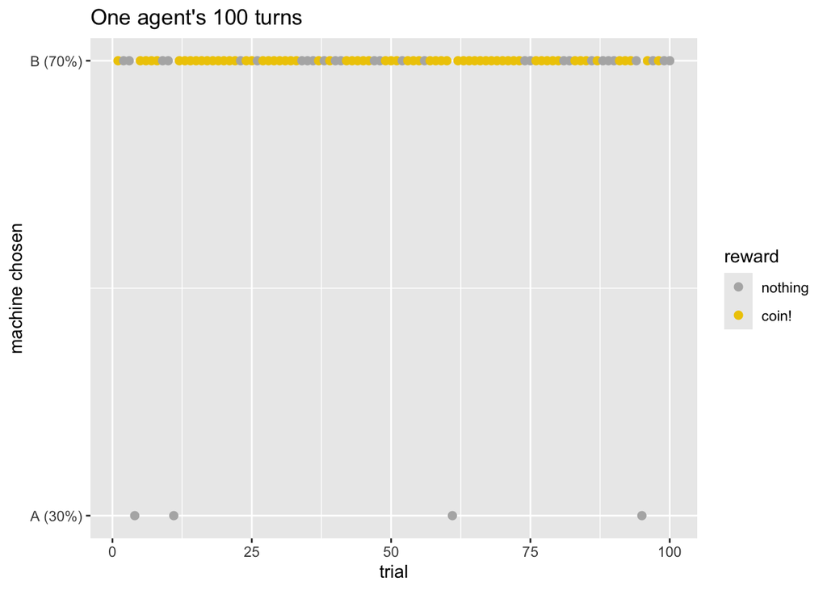

```r
library(ggplot2)
set.seed(1)

one_life <- simulate_learner()
ggplot(one_life, aes(x = trial, y = choice)) +
  geom_point(aes(color = factor(reward)), size = 2) +
  scale_y_continuous(breaks = c(1, 2), labels = c("A (30%)", "B (70%)")) +
  scale_color_manual(values = c("grey70", "gold2"), name = "reward",
                     labels = c("nothing", "coin!")) +
  labs(title = "One agent's 100 turns", y = "machine chosen")
```

## The learning curve

One agent is noisy. Let’s average **1000 agents** to see the typical pattern:

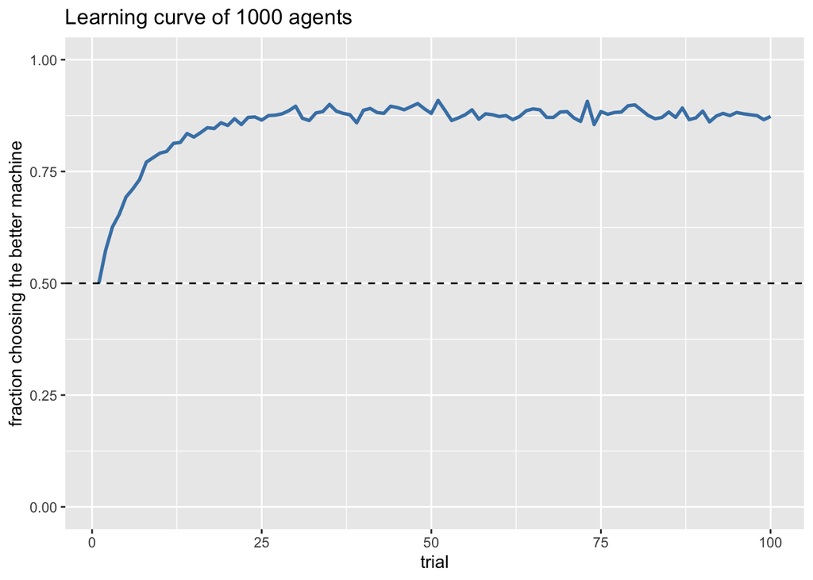

```r
# Run 1000 agents, then glue their result tables into one big table.
many <- do.call(rbind, lapply(1:1000, function(i) simulate_learner()))
# For each trial, average across agents.
curve <- aggregate(chose_best ~ trial,
                   data = transform(many, chose_best = as.numeric(choice == 2)),
                   FUN = mean)

ggplot(curve, aes(trial, chose_best)) +
  geom_line(linewidth = 1, color = "steelblue") +
  geom_hline(yintercept = 0.5, linetype = "dashed") +
  ylim(0, 1) +
  labs(title = "Learning curve of 1000 agents",
       y = "fraction choosing the better machine")
```

**TipTry it! — become a parameter scientist**

Change one parameter at a time and re-run the learning-curve code. Before each run, **write down your prediction**!

1. `alpha = 0.05` (very slow learner) — what happens to the curve?
2. `alpha = 1` (only the last experience counts) — better or worse? Why?
3. `beta = 0` — what does the curve look like now?
4. Make the problem *hard*: `reward_probs = c(0.45, 0.55)`. How well do agents do? How is this like real life?

**ImportantThe big idea**

$\alpha$ and $\beta$ are called **parameters**. Different parameter values = different “personalities” of learner. When researchers fit these parameters to real people’s choices, they can *measure* how individuals learn. That is **computational modelling of behaviour** — the field this camp is about, and the topic of active research at RIKEN.

## What you learned

- The bandit problem: explore vs exploit
- Agents learn by **prediction error** (Rescorla–Wagner rule), scaled by learning rate $\alpha$
- Softmax turns value estimates into choices; $\beta$ sets curiosity vs greed
- Averaging many simulated agents reveals the *typical* behaviour of a model

These functions are saved in `R/bandit_functions.R`, so next time we can just load them with `source("R/bandit_functions.R")`.

Next tutorial: our agent stops being alone. **What happens when agents can watch each other?**